# Exploratory data analysis (EDA) of missing data

CSP 2021

Emile Latour

February 17, 2021

# Load the packages

Here we load that packages that we will be using during the analysis. See section titled “Links and references” for more info on the packages

```r
library(tidyverse)       # packages ggplot2, dplyr, tidyr, readr, purrr, tibble,
# stringr, and forcats
library(broom)           # functions tidy(), glance(), augment()
library(janitor)         # for working with dirty data
library(here)            # simpler way to find your files
library(skimr)           # Compact and Flexible Summaries of Data

library(mice)            # Multiple imputation using Fully Conditional Specification
library(naniar)          # structures, summaries, and visualizations for missing data
library(VIM)             # Visualization and Imputation of Missing Values
library(finalfit)        # Check for associations between missing and observed data.
```

# The data

A simulated data set of Medicaid enrollment data that has been matched with Electronic Health Records (EHR) for the purposes of comparing the Medicaid claims data with the EHR to ensure accuracy/agreement.

The data contains:

- Demographic information: age, sex, race, ethnicity, language spoken, and Federal poverty level status (FPL).
- Eligible (Yes/No) for Breast cancer screening, Cholesterol screening, and Flu vaccine.
- Received (Yes/No) according to Medicaid data for each.
- Received (Yes/No) according to EHR data for each.
- Total cholesterol values for those that received cholesterol screening in the EHR.

## Based on real data

To provide a practical real-world example, he data used here was based on an actual data set, but due to complications with using patient data and privacy, all data here has been simulated and similarities to the original data are unintentional.

# Data preparation

## Load the data

Using the `here` package to construct the path to the data set. Specifying the column types ahead of time.

```r
data <- readr::read_csv(
  file = here::here("data",
                    "ehr-and-claims_simulated-data_csp-2021.csv"),
  col_types = cols(pat_id = col_character(),
                   age = col_double(),
                   sex = col_character(),
                   race_eth = col_character(),
                   language = col_character(),
                   fpl = col_character(),
                   age_f = col_character(),
                   breast_eligibility = col_double(),
                   flu_eligibility = col_double(),
                   cholesterol_eligibility = col_double(),
                   breast_claims = col_double(),
                   flu_claims = col_double(),
                   cholesterol_claims = col_double(),
                   breast_ehr = col_double(),
                   flu_ehr = col_double(),
                   cholesterol_ehr = col_double(),
                   cholesterol_total = col_double()))
```

## Take a peak

Take note of

- The number of rows and columns,
- Variable names,
- Types of variables,
- Some of the data values

```r
dplyr::glimpse(data)
```

```
## Rows: 13,101
## Columns: 17
## $ pat_id                  <chr> "05094", "05711", "01013", "11608", "12443", …
## $ age                     <dbl> NA, 48, 26, 59, 61, 34, 54, 59, 50, 40, NA, 6…
## $ sex                     <chr> "Female", "Female", "Female", "Male", "Female…
## $ race_eth                <chr> "Non-Hispanic, White", "Non-Hispanic, White",…
## $ language                <chr> "English", "English", "English", "English", "…
## $ fpl                     <chr> "<=138% FPL", "<=138% FPL", "<=138% FPL", "<=…
## $ age_f                   <chr> NA, "35-<50", "19-<34", "51-<64", "51-<64", "…
## $ breast_eligibility      <dbl> 1, 1, 0, 0, 1, 0, 0, 1, 0, 0, 0, 1, 0, 0, 1, …
## $ flu_eligibility         <dbl> 1, 0, 0, 1, 1, 0, 1, 1, 0, 0, 1, 1, 1, 0, 0, …
## $ cholesterol_eligibility <dbl> 1, 1, 1, 1, 1, 1, 1, 1, 1, 1, 1, 1, 1, 1, 1, …
## $ breast_claims           <dbl> 1, 0, 0, 0, 0, 0, 0, 1, 0, 0, 0, 0, 0, 0, 0, …
## $ flu_claims              <dbl> 0, 0, 0, 1, 0, 0, 1, 0, 0, 0, 0, 0, 1, 0, 0, …
## $ cholesterol_claims      <dbl> 1, 0, 0, 1, 1, 1, 1, 0, 0, 0, 1, 1, 1, 0, 1, …
## $ breast_ehr              <dbl> 1, 0, 0, 0, 0, 0, 0, 0, 0, 0, 0, 0, 0, 0, 1, …
## $ flu_ehr                 <dbl> 0, 0, 1, 1, 0, 1, 1, 0, 0, 0, 0, 0, 1, 0, 0, …
## $ cholesterol_ehr         <dbl> 1, 0, 0, 1, 0, 1, 1, 0, 0, 0, 1, 0, 1, 0, 1, …
## $ cholesterol_total       <dbl> 152.9439, NA, NA, 193.5783, NA, 226.7804, 244…
```

## Light data cleaning

Convert coded variables to `factor` type.

```r
data <- data %>%
  mutate(sex = factor(sex,
                      levels = c("Female", "Male")),
         race_eth = factor(race_eth,
                           levels = c("Hispanic",
                                      "Non-Hispanic, Black",
                                      "Non-Hispanic, Other",
                                      "Non-Hispanic, White")),
         language = factor(language,
                           levels = c("English",
                                      "Spanish",
                                      "Other")),
         fpl = factor(fpl,
                      levels = c("<=138% FPL",
                                 ">138% FPL")),
         age_f = factor(age_f,
                        levels = c("19-<34",
                                   "35-<50",
                                   "51-<64")),
         dplyr::across(.cols = dplyr::ends_with("_eligibility"),
                       .fns = ~ factor(.,
                                       levels = c(1, 0),
                                       labels = c("Yes", "No"))),
         dplyr::across(.cols = dplyr::ends_with("_claims"),
                       .fns = ~ factor(.,
                                       levels = c(1, 0),
                                       labels = c("Yes", "No"))),
         dplyr::across(.cols = dplyr::ends_with("_ehr"),
                       .fns = ~ factor(.,
                                       levels = c(1, 0),
                                       labels = c("Yes", "No")))
  )

# Good step I always do to ensure consistent, clean naming conventions
data <- data %>%
  janitor::clean_names()
```

## One more peak

Take another glimpse at the data and note how the values have changed.

```r
dplyr::glimpse(data)
```

```
## Rows: 13,101
## Columns: 17
## $ pat_id                  <chr> "05094", "05711", "01013", "11608", "12443", …
## $ age                     <dbl> NA, 48, 26, 59, 61, 34, 54, 59, 50, 40, NA, 6…
## $ sex                     <fct> Female, Female, Female, Male, Female, Male, M…
## $ race_eth                <fct> "Non-Hispanic, White", "Non-Hispanic, White",…
## $ language                <fct> English, English, English, English, Spanish, …
## $ fpl                     <fct> <=138% FPL, <=138% FPL, <=138% FPL, <=138% FP…
## $ age_f                   <fct> NA, 35-<50, 19-<34, 51-<64, 51-<64, 19-<34, 5…
## $ breast_eligibility      <fct> Yes, Yes, No, No, Yes, No, No, Yes, No, No, N…
## $ flu_eligibility         <fct> Yes, No, No, Yes, Yes, No, Yes, Yes, No, No, …
## $ cholesterol_eligibility <fct> Yes, Yes, Yes, Yes, Yes, Yes, Yes, Yes, Yes, …
## $ breast_claims           <fct> Yes, No, No, No, No, No, No, Yes, No, No, No,…
## $ flu_claims              <fct> No, No, No, Yes, No, No, Yes, No, No, No, No,…
## $ cholesterol_claims      <fct> Yes, No, No, Yes, Yes, Yes, Yes, No, No, No, …
## $ breast_ehr              <fct> Yes, No, No, No, No, No, No, No, No, No, No, …
## $ flu_ehr                 <fct> No, No, Yes, Yes, No, Yes, Yes, No, No, No, N…
## $ cholesterol_ehr         <fct> Yes, No, No, Yes, No, Yes, Yes, No, No, No, Y…
## $ cholesterol_total       <dbl> 152.9439, NA, NA, 193.5783, NA, 226.7804, 244…
```

# Skim the data

`skimr::skim()` is a nice alternative to the base R function `summary()`. Though it doesn’t always play nicely depending on your operating system…

```r
# With spark graphs if system allows
# skimr::skim(data)

# Without spark graphs
skimr::skim_without_charts(data)
```

Data summary

| Name | data |
| --- | --- |
| Number of rows | 13101 |
| Number of columns | 17 |
| _______________________ |  |
| Column type frequency: |  |
| character | 1 |
| factor | 14 |
| numeric | 2 |
| ________________________ |  |
| Group variables | None |

**Variable type: character**

| skim_variable | n_missing | complete_rate | min | max | empty | n_unique | whitespace |
| --- | --- | --- | --- | --- | --- | --- | --- |
| pat_id | 0 | 1 | 5 | 5 | 0 | 13101 | 0 |

**Variable type: factor**

| skim_variable | n_missing | complete_rate | ordered | n_unique | top_counts |
| --- | --- | --- | --- | --- | --- |
| sex | 1313 | 0.90 | FALSE | 2 | Fem: 7759, Mal: 4029 |
| race_eth | 551 | 0.96 | FALSE | 4 | Non: 8897, Non: 1406, His: 1226, Non: 1021 |
| language | 0 | 1.00 | FALSE | 3 | Eng: 10948, Oth: 1523, Spa: 630 |
| fpl | 2813 | 0.79 | FALSE | 2 | <=1: 10062, >13: 226 |
| age_f | 1947 | 0.85 | FALSE | 3 | 19-: 4306, 35-: 4095, 51-: 2753 |
| breast_eligibility | 0 | 1.00 | FALSE | 2 | No: 8845, Yes: 4256 |
| flu_eligibility | 0 | 1.00 | FALSE | 2 | No: 9424, Yes: 3677 |
| cholesterol_eligibility | 0 | 1.00 | FALSE | 2 | Yes: 12797, No: 304 |
| breast_claims | 0 | 1.00 | FALSE | 2 | No: 11467, Yes: 1634 |
| flu_claims | 0 | 1.00 | FALSE | 2 | No: 11856, Yes: 1245 |
| cholesterol_claims | 0 | 1.00 | FALSE | 2 | No: 7775, Yes: 5326 |
| breast_ehr | 0 | 1.00 | FALSE | 2 | No: 11550, Yes: 1551 |
| flu_ehr | 0 | 1.00 | FALSE | 2 | No: 8789, Yes: 4312 |
| cholesterol_ehr | 0 | 1.00 | FALSE | 2 | No: 8042, Yes: 5059 |

**Variable type: numeric**

| skim_variable | n_missing | complete_rate | mean | sd | p0 | p25 | p50 | p75 | p100 |
| --- | --- | --- | --- | --- | --- | --- | --- | --- | --- |
| age | 1947 | 0.85 | 39.68 | 12.69 | 19.00 | 29.00 | 39.00 | 49.0 | 64.00 |
| cholesterol_total | 8042 | 0.39 | 199.63 | 42.90 | 47.23 | 170.67 | 199.48 | 227.7 | 353.94 |

# Explore missingness

When working with missing data in R, there are lots of packages that can be really helpful. [mice](https://www.gerkovink.com/miceVignettes/Missingness_inspection/Missingness_inspection.html) has some great functions that Van Buuren highlights. The [`VIM`](https://cran.r-project.org/web/packages/VIM/index.html) package has some great tools as well. My preference is to use the [`naniar`](https://cran.r-project.org/web/packages/naniar/index.html) package for inspecting missingness.

## `naniar`

The naniar package provides a number of visual summaries that I find helpful, in addition, there are some very nice clean numeric summaries as well.

With all my data sets, I will examine an missingness plot and a sorted/clustered version to get an overview of any missingness problems in my data.

# Missingness plot

## Unsorted

```r
data %>%
  naniar::vis_miss()
```

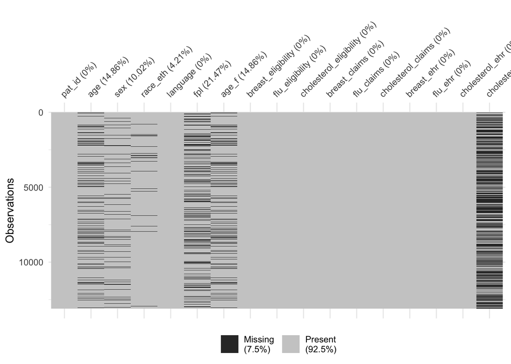

## Sorted and clustered

```r
data %>%
  naniar::vis_miss(.,
                   sort_miss = TRUE,
                   cluster = TRUE)
```

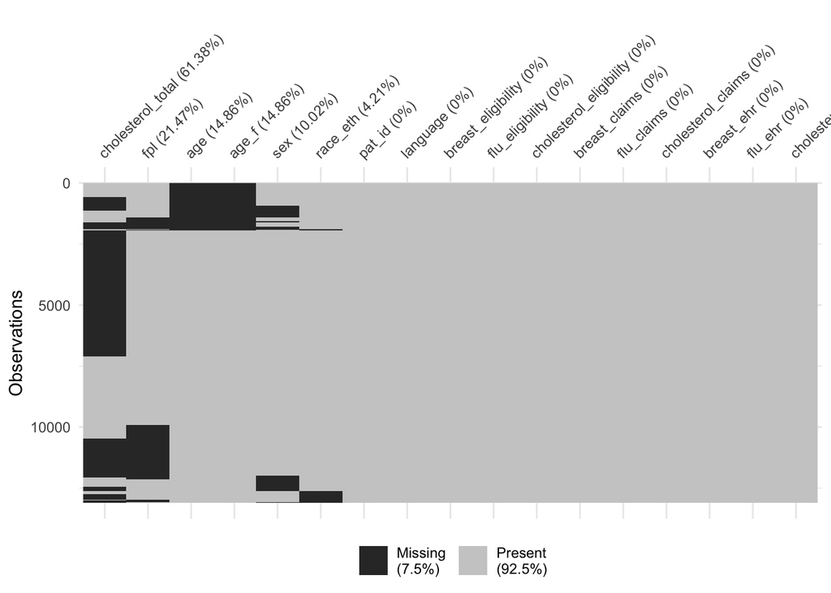

## Clustered, sorted, and filtered

With really large data sets, I will filter to just the variables with any missingness prior to making this plot, or filter to just the relevant data since with large data this figure can get messy.

Also, the options in `naniar::vis_miss()` to *cluster* and to *sort* the data are really helpful.

```r
data %>%
  dplyr::select_if(.tbl = .,
                   .predicate = naniar::any_na) %>%
  naniar::vis_miss(.,
                   cluster = TRUE,
                   sort_miss = TRUE)
```

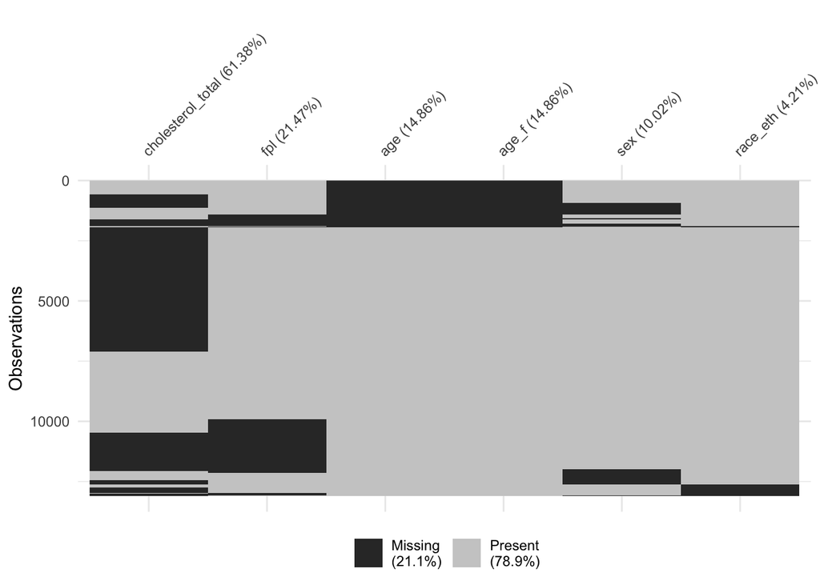

# Upset plot

Visualization to further explore the patterns of missingness, specifically the combinations (i.e. intersections) of missing values across cases.

```r
data %>%
  naniar::gg_miss_upset(.,
                        nsets = 6)
```

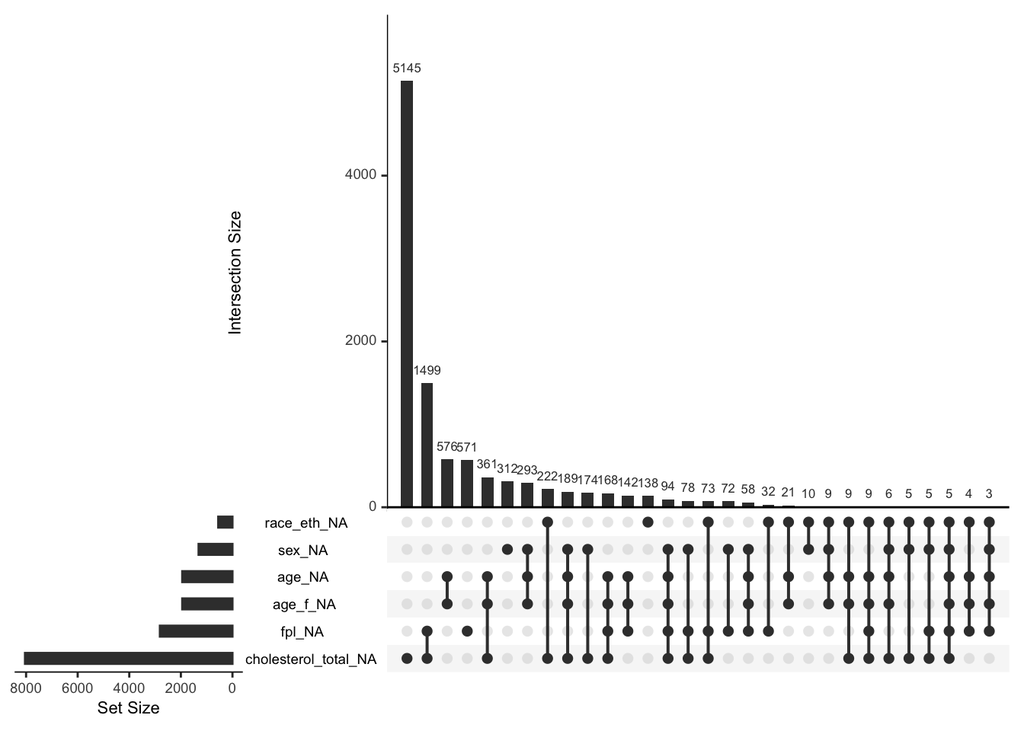

# Numeric summaries

I addition to visualizing missingness, it’s important to quantify the missingness of the data:

- Number and percentage of records/cases (rows) with missing data
- Number and percentage of variables (columns) with missing data
- Number and percentage of cells with missing data

# Complete and incomplete cases

Number and percentage of complete / missing cases

```r
data %>%
  summarise(n_complete = sum(stats::complete.cases(.)),
            pct_complete = 100 * naniar::prop_complete_case(.),
            n_missing = sum(!stats::complete.cases(.)),
            pct_missing = 100 * naniar::prop_miss_case(.))
```

```
## # A tibble: 1 x 4
##   n_complete pct_complete n_missing pct_missing
##        <int>        <dbl>     <int>       <dbl>
## 1       2818         21.5     10283        78.5
```

# Complete and incomplete cases

How many missing values does each case have?

```r
data %>%
  naniar::miss_case_table()
```

```
## # A tibble: 7 x 3
##   n_miss_in_case n_cases pct_cases
## *          <int>   <int>     <dbl>
## 1              0    2818   21.5
## 2              1    6166   47.1
## 3              2    2585   19.7
## 4              3     973    7.43
## 5              4     442    3.37
## 6              5     112    0.855
## 7              6       5    0.0382
```

# Missingness by variable

The number and percentage of missing values for each variable / column

```r
data %>%
  naniar::miss_var_summary() %>%
  dplyr::filter(n_miss > 0)  # Filter to just those variables with non-zero number of missing
```

```
## # A tibble: 6 x 3
##   variable          n_miss pct_miss
##   <chr>              <int>    <dbl>
## 1 cholesterol_total   8042    61.4
## 2 fpl                 2813    21.5
## 3 age                 1947    14.9
## 4 age_f               1947    14.9
## 5 sex                 1313    10.0
## 6 race_eth             551     4.21
```

# Complete and incomplete values in the data

```r
data %>%
  naniar::miss_prop_summary()
```

```
## # A tibble: 1 x 3
##       df   var  case
##    <dbl> <dbl> <dbl>
## 1 0.0746 0.353 0.785
```

# `VIM`

The VIM package is very useful for missingness EDA. In one figure below, we get information about the missingness by variable and good information about the patterns.

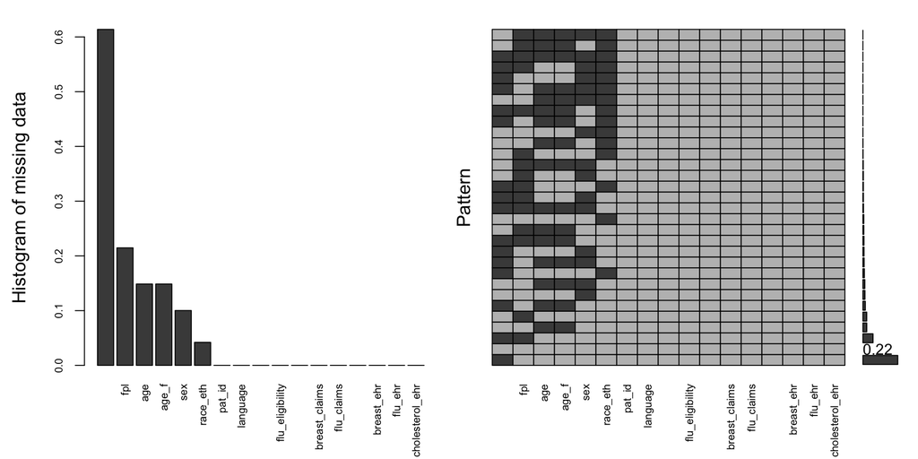

```
##
##  Variables sorted by number of missings:
##                 Variable      Count
##        cholesterol_total 0.61384627
##                      fpl 0.21471643
##                      age 0.14861461
##                    age_f 0.14861461
##                      sex 0.10022136
##                 race_eth 0.04205786
##                   pat_id 0.00000000
##                 language 0.00000000
##       breast_eligibility 0.00000000
##          flu_eligibility 0.00000000
##  cholesterol_eligibility 0.00000000
##            breast_claims 0.00000000
##               flu_claims 0.00000000
##       cholesterol_claims 0.00000000
##               breast_ehr 0.00000000
##                  flu_ehr 0.00000000
##          cholesterol_ehr 0.00000000
```

```r
data %>%
  VIM::aggr(.,
            col = c("gray", "gray29"),
            numbers = TRUE,
            sortVars = TRUE,
            labels = names(.),
            only.miss = TRUE,
            cex.axis = .7,
            gap = 3,
            ylab = c("Histogram of missing data","Pattern"))
```

## Filtered to just columns with missing

With this one it can also be helpful to select on the columns with missing data first and examine the patterns.

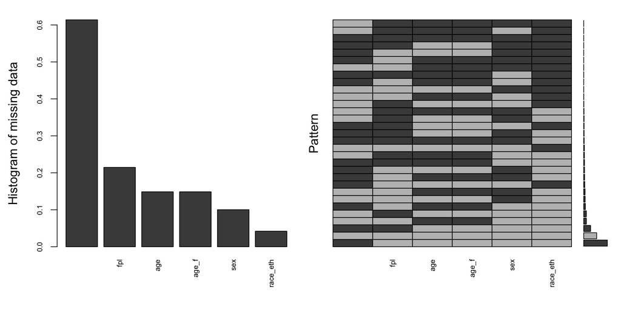

```
##
##  Variables sorted by number of missings:
##           Variable      Count
##  cholesterol_total 0.61384627
##                fpl 0.21471643
##                age 0.14861461
##              age_f 0.14861461
##                sex 0.10022136
##           race_eth 0.04205786
```

```r
data %>%
  dplyr::select_if(.tbl = .,
                   .predicate = naniar::any_na) %>%
  VIM::aggr(.,
            col = c("gray", "gray29"),
            numbers = TRUE,
            sortVars = TRUE,
            labels = names(.),
            cex.axis = .7,
            gap = 3,
            ylab = c("Histogram of missing data","Pattern"))
```

# `mice`

The `mice` package will be used for imputation later. It’s also got some handy tools for exploring the missingness in data sets.

The functions in `mice` for EDA mostly help when deciding what variables may or may not be good predictors in the imputation models.

# Pattern

Numeric and visual representation of the pattern. Doesn’t always print well for me. Looks better in R/Rstudio console

- Left = Number of cases/rows with a pattern
- Right = Number of missing columns

```r
data %>%
  mice::md.pattern(.,
                   rotate.names = TRUE)
```

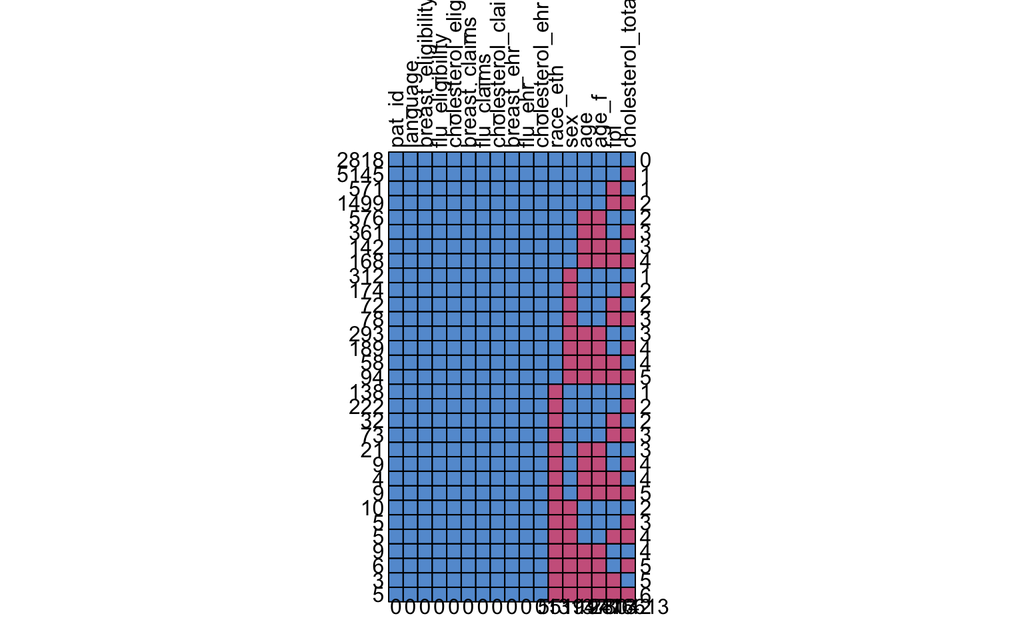

```
##      pat_id language breast_eligibility flu_eligibility cholesterol_eligibility
## 2818      1        1                  1               1                       1
## 5145      1        1                  1               1                       1
## 571       1        1                  1               1                       1
## 1499      1        1                  1               1                       1
## 576       1        1                  1               1                       1
## 361       1        1                  1               1                       1
## 142       1        1                  1               1                       1
## 168       1        1                  1               1                       1
## 312       1        1                  1               1                       1
## 174       1        1                  1               1                       1
## 72        1        1                  1               1                       1
## 78        1        1                  1               1                       1
## 293       1        1                  1               1                       1
## 189       1        1                  1               1                       1
```

[output cut: 84 more lines]

# Pattern

Again, a little easier to look at this with just the columns that have any missing values.

```r
data %>%
  dplyr::select_if(.tbl = .,
                   .predicate = naniar::any_na) %>%
  mice::md.pattern(.,
                   rotate.names = TRUE)
```

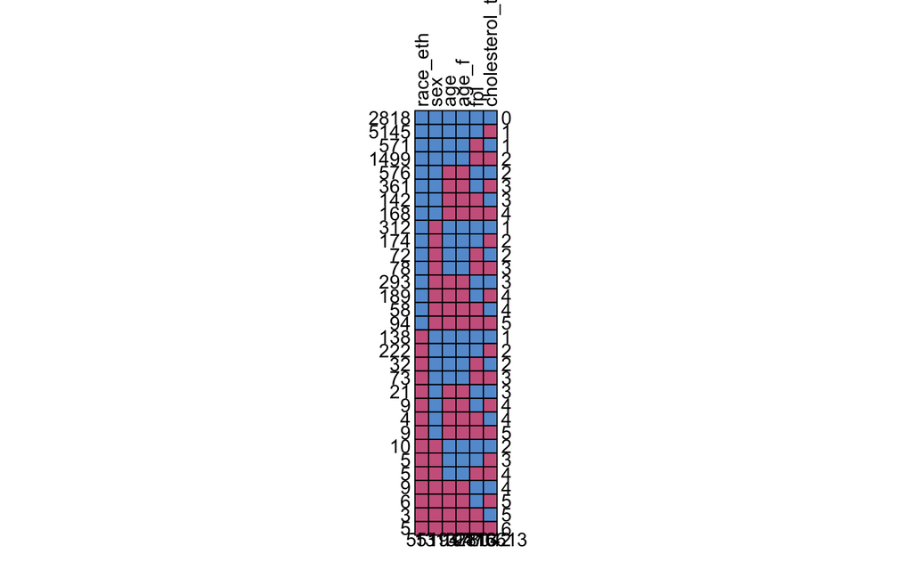

```
##      race_eth  sex  age age_f  fpl cholesterol_total
## 2818        1    1    1     1    1                 1     0
## 5145        1    1    1     1    1                 0     1
## 571         1    1    1     1    0                 1     1
## 1499        1    1    1     1    0                 0     2
## 576         1    1    0     0    1                 1     2
## 361         1    1    0     0    1                 0     3
## 142         1    1    0     0    0                 1     3
## 168         1    1    0     0    0                 0     4
## 312         1    0    1     1    1                 1     1
## 174         1    0    1     1    1                 0     2
## 72          1    0    1     1    0                 1     2
## 78          1    0    1     1    0                 0     3
## 293         1    0    0     0    1                 1     3
## 189         1    0    0     0    1                 0     4
```

[output cut: 18 more lines]

# Missingness pairs

Four missingness patterns:

- `rr` both are observed,
- `rm` first (left) variable is observed, the second (top) is missing,
- `mr` first (left) variable is missing, the second (top) is observed, and
- `mm` both variable are missing.

```r
mssng_pairs <- data %>%
  dplyr::select_if(.tbl = .,
                   .predicate = naniar::any_na) %>%
  mice::md.pairs(.)

mssng_pairs
```

```
## $rr
##                     age   sex race_eth   fpl age_f cholesterol_total
## age               11154 10498    10669  8824 11154              3953
## sex               10498 11788    11280  9290 10498              4302
## race_eth          10669 11280    12550  9868 10669              4842
## fpl                8824  9290     9868 10288  8824              4177
## age_f             11154 10498    10669  8824 11154              3953
## cholesterol_total  3953  4302     4842  4177  3953              5059
##
## $rm
##                    age  sex race_eth  fpl age_f cholesterol_total
## age                  0  656      485 2330     0              7201
## sex               1290    0      508 2498  1290              7486
## race_eth          1881 1270        0 2682  1881              7708
## fpl               1464  998      420    0  1464              6111
## age_f                0  656      485 2330     0              7201
## cholesterol_total 1106  757      217  882  1106                 0
##
## $mr
##                    age  sex race_eth  fpl age_f cholesterol_total
## age                  0 1290     1881 1464     0              1106
## sex                656    0     1270  998   656               757
## race_eth           485  508        0  420   485               217
## fpl               2330 2498     2682    0  2330               882
## age_f                0 1290     1881 1464     0              1106
## cholesterol_total 7201 7486     7708 6111  7201                 0
##
## $mm
##                    age  sex race_eth  fpl age_f cholesterol_total
## age               1947  657       66  483  1947               841
## sex                657 1313       43  315   657               556
## race_eth            66   43      551  131    66               334
## fpl                483  315      131 2813   483              1931
## age_f             1947  657       66  483  1947               841
## cholesterol_total  841  556      334 1931   841              8042
```

# Proportion of usable cases

Measures how many cases with missing data on the target variable actually have observed values on the predictor. The proportion will be low if both target and predictor are missing on the same cases.

Target on the vertical axis (i.e. left), predictor on the horizontal (i.e. top).

This gives a sense of what variables may be good to include/exclude in the imputation model. Higher % indicates more information and likely good predictor; lower % indicates that the variables are missing for the same observations and may not be good predictor.

```r
prop_usable_cases <- mssng_pairs %>%
  with(.,
       round(mr / (mr + mm), digits = 3))

prop_usable_cases
```

```
##                     age   sex race_eth   fpl age_f cholesterol_total
## age               0.000 0.663    0.966 0.752 0.000             0.568
## sex               0.500 0.000    0.967 0.760 0.500             0.577
## race_eth          0.880 0.922    0.000 0.762 0.880             0.394
## fpl               0.828 0.888    0.953 0.000 0.828             0.314
## age_f             0.000 0.663    0.966 0.752 0.000             0.568
## cholesterol_total 0.895 0.931    0.958 0.760 0.895             0.000
```

# Outbound statistic

How observed data in a variable connect to missing data in the rest of the data.

Here lower is better. Looking at the top line for `age`: `sex` and `race_eth` may be better predictors than `fpl`.

```r
mssng_pairs %>%
  with(.,
       round(rm / (rm + rr), digits = 3))
```

```
##                     age   sex race_eth   fpl age_f cholesterol_total
## age               0.000 0.059    0.043 0.209 0.000             0.646
## sex               0.109 0.000    0.043 0.212 0.109             0.635
## race_eth          0.150 0.101    0.000 0.214 0.150             0.614
## fpl               0.142 0.097    0.041 0.000 0.142             0.594
## age_f             0.000 0.059    0.043 0.209 0.000             0.646
## cholesterol_total 0.219 0.150    0.043 0.174 0.219             0.000
```

# Influx and Ouflux

Two overall measures of how each variable connects to the others. Van Buuren says:

> For two variables with the same proportion of missing data, the variable with higher influx is better connected to the observed data, and might thus be easier to impute.

> For two variables having the same proportion of missing data, the variable with higher outflux is better connected to the missing data, and thus potentially more useful for imputing other variables.

> Influx and outflux are summaries of the missing data pattern intended to aid in the construction of imputation models. Keeping everything else constant, variables with high influx and outflux are preferred.

See Van Buuren for details on these ([link](https://stefvanbuuren.name/fimd/missing-data-pattern.html))

```r
mice::flux(data)[, 1:3]
```

```
##                              pobs     influx   outflux
## pat_id                  1.0000000 0.00000000 1.0000000
## age                     0.8513854 0.13176843 0.6423885
## sex                     0.8997786 0.09111905 0.7868537
## race_eth                0.9579421 0.03966929 0.9283092
## language                1.0000000 0.00000000 1.0000000
## fpl                     0.7852836 0.20215522 0.6294468
## age_f                   0.8513854 0.13176843 0.6423885
## breast_eligibility      1.0000000 0.00000000 1.0000000
## flu_eligibility         1.0000000 0.00000000 1.0000000
## cholesterol_eligibility 1.0000000 0.00000000 1.0000000
## breast_claims           1.0000000 0.00000000 1.0000000
## flu_claims              1.0000000 0.00000000 1.0000000
## cholesterol_claims      1.0000000 0.00000000 1.0000000
## breast_ehr              1.0000000 0.00000000 1.0000000
## flu_ehr                 1.0000000 0.00000000 1.0000000
## cholesterol_ehr         1.0000000 0.00000000 1.0000000
## cholesterol_total       0.3861537 0.60245798 0.2448685
```

# Influx and Outflux

Visualization of influx and outflux. Again, from Van Buuren:

> In general, variables that are located higher up in the display are more complete and thus potentially more useful for imputation. …in practice variables closer to the subdiagonal are typically better connected than those farther away. The fluxplot can be used to spot variables that clutter the imputation model. Variables that are located in the lower regions (especially near the lower-left corner) and that are uninteresting for later analysis are better removed from the data prior to imputation.

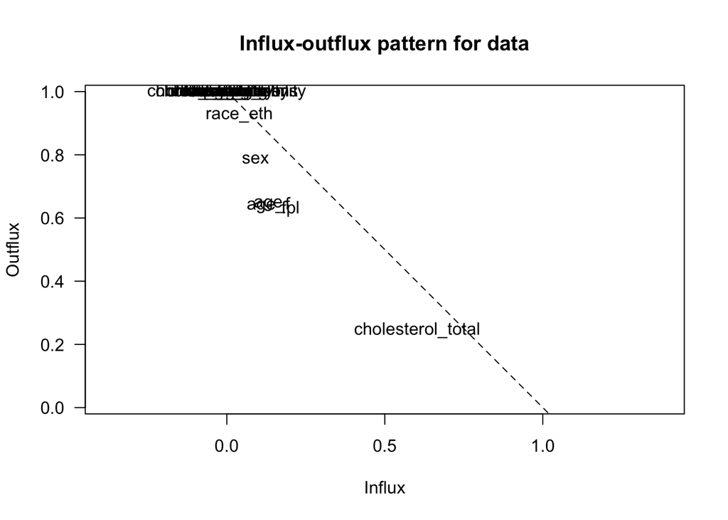

```r
mice::fluxplot(data)
```

`race_eth` and `sex` appear useful for imputation, but `fpl` and `age` do not. `cholesterol_total` doesn’t look very helpful.

# `finalfit`

Just recently came across this package. There is a very nice article about the functions available for working with missing data ([link](https://finalfit.org/articles/missing.html)).

Here I want to highlight two very helpful ways the package can help to see if the data is missing for any particular reason.

According to the authors:

> In deciding whether data is MCAR or MAR, one approach is to explore patterns of missingness between levels of included variables. This is particularly important (I would say absolutely required) for a primary outcome measure / dependent variable.

# `missing_pairs`

Visually check for different missingness across levels of the variables in the data set.

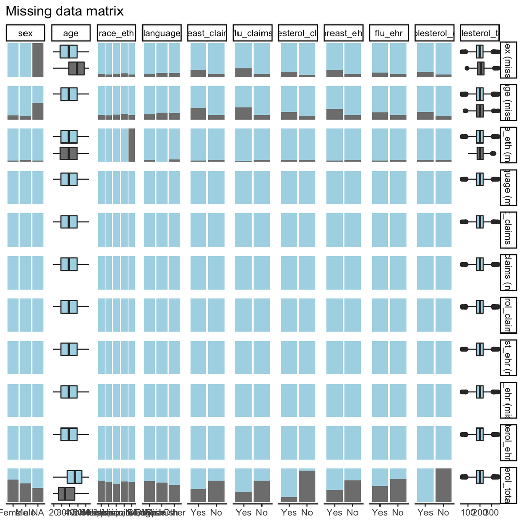

```r
data %>%
  finalfit::missing_pairs(dependent = "sex",
                          explanatory = c("age",
                                          "race_eth",
                                          "language",
                                          "breast_claims",
                                          "flu_claims",
                                          "cholesterol_claims",
                                          "breast_ehr",
                                          "flu_ehr",
                                          "cholesterol_ehr",
                                          "cholesterol_total"),
                          position = "fill")
```

# `missing_compare`

Check associations with missingness (observed or missing) of a particular variable. Some justification here to assume MAR and not MCAR. No way to tell MCAR here.

```r
data %>%
  finalfit::missing_compare(dependent = "sex",
                            explanatory = c("age",
                                            "race_eth",
                                            "language",
                                            "breast_claims",
                                            "flu_claims",
                                            "cholesterol_claims",
                                            "breast_ehr",
                                            "flu_ehr",
                                            "cholesterol_ehr",
                                            "cholesterol_total")) %>%
  knitr::kable(row.names=FALSE, align = c("l", "l", "r", "r", "r"))
```

| Missing data analysis: sex |  | Not missing | Missing | p |
| --- | --- | --- | --- | --- |
| age | Mean (SD) | 39.2 (12.6) | 47.7 (11.8) | <0.001 |
| race_eth | Hispanic | 1122 (91.5) | 104 (8.5) | <0.001 |
|  | Non-Hispanic, Black | 1309 (93.1) | 97 (6.9) |  |
|  | Non-Hispanic, Other | 925 (90.6) | 96 (9.4) |  |
|  | Non-Hispanic, White | 7924 (89.1) | 973 (10.9) |  |
| language | English | 9894 (90.4) | 1054 (9.6) | 0.003 |
|  | Spanish | 553 (87.8) | 77 (12.2) |  |
|  | Other | 1341 (88.0) | 182 (12.0) |  |
| breast_claims | Yes | 1296 (79.3) | 338 (20.7) | <0.001 |
|  | No | 10492 (91.5) | 975 (8.5) |  |
| flu_claims | Yes | 939 (75.4) | 306 (24.6) | <0.001 |
|  | No | 10849 (91.5) | 1007 (8.5) |  |
| cholesterol_claims | Yes | 4536 (85.2) | 790 (14.8) | <0.001 |
|  | No | 7252 (93.3) | 523 (6.7) |  |
| breast_ehr | Yes | 1230 (79.3) | 321 (20.7) | <0.001 |
|  | No | 10558 (91.4) | 992 (8.6) |  |
| flu_ehr | Yes | 3721 (86.3) | 591 (13.7) | <0.001 |
|  | No | 8067 (91.8) | 722 (8.2) |  |
| cholesterol_ehr | Yes | 4302 (85.0) | 757 (15.0) | <0.001 |
|  | No | 7486 (93.1) | 556 (6.9) |  |
| cholesterol_total | Mean (SD) | 198.1 (42.9) | 208.1 (41.7) | <0.001 |

# `missing_compare`

Check associations with missingness (observed or missing) of a particular variable. Some justification here to assume MAR and not MCAR. No way to tell MCAR here.

```r
data %>%
  finalfit::missing_compare(dependent = "race_eth",
                            explanatory = c("sex",
                                            "age",
                                            "language",
                                            "breast_claims",
                                            "flu_claims",
                                            "cholesterol_claims",
                                            "breast_ehr",
                                            "flu_ehr",
                                            "cholesterol_ehr",
                                            "cholesterol_total")) %>%
  knitr::kable(row.names=FALSE, align = c("l", "l", "r", "r", "r"))
```

| Missing data analysis: race_eth |  | Not missing | Missing | p |
| --- | --- | --- | --- | --- |
| sex | Female | 7475 (96.3) | 284 (3.7) | <0.001 |
|  | Male | 3805 (94.4) | 224 (5.6) |  |
| age | Mean (SD) | 39.7 (12.7) | 39.1 (12.6) | 0.328 |
| language | English | 10502 (95.9) | 446 (4.1) | <0.001 |
|  | Spanish | 630 (100.0) | 0 (0.0) |  |
|  | Other | 1418 (93.1) | 105 (6.9) |  |
| breast_claims | Yes | 1582 (96.8) | 52 (3.2) | 0.033 |
|  | No | 10968 (95.6) | 499 (4.4) |  |
| flu_claims | Yes | 1214 (97.5) | 31 (2.5) | 0.002 |
|  | No | 11336 (95.6) | 520 (4.4) |  |
| cholesterol_claims | Yes | 5102 (95.8) | 224 (4.2) | 1.000 |
|  | No | 7448 (95.8) | 327 (4.2) |  |
| breast_ehr | Yes | 1495 (96.4) | 56 (3.6) | 0.239 |
|  | No | 11055 (95.7) | 495 (4.3) |  |
| flu_ehr | Yes | 4149 (96.2) | 163 (3.8) | 0.098 |
|  | No | 8401 (95.6) | 388 (4.4) |  |
| cholesterol_ehr | Yes | 4842 (95.7) | 217 (4.3) | 0.739 |
|  | No | 7708 (95.8) | 334 (4.2) |  |
| cholesterol_total | Mean (SD) | 199.5 (42.8) | 202.0 (45.1) | 0.395 |

# References and links

## Packages

### General purpose / very, very useful

- [tidyverse](https://www.tidyverse.org/)
- [broom](https://cran.r-project.org/web/packages/broom/index.html)
- [janitor](https://cran.r-project.org/web/packages/janitor/index.html)
- [here](https://cran.r-project.org/web/packages/here/index.html)
- [skimr](https://cran.r-project.org/web/packages/skimr/index.html)

### Missing data EDA

- [mice](https://cran.r-project.org/web/packages/mice/mice.pdf)
- [naniar](https://cran.r-project.org/web/packages/naniar/index.html)
- [VIM](https://cran.r-project.org/web/packages/VIM/index.html)
- [finalfit](https://finalfit.org/articles/missing.html)

## Books

- [Flexible Imputaion of Missing Data, Van Buuren](https://stefvanbuuren.name/fimd/) with [this specific section on missing data pattern](https://stefvanbuuren.name/fimd/missing-data-pattern.html)